# AP-4209 ESIEE-Paris: 2025 - 2026

Fouille de données

PROJET 2 : ANALYSE FACTORIELLE DISCRIMINANTE SUR DONNÉES TEXTUELLES (NLP)

– Twitter Entity Sentiment Analysis –

Auteur : Meliana ZERROUG, Keren BENADIBA– ESIEE Paris

### 1. Introduction et Objectifs

Le but de ce projet est d’appliquer l’Analyse Factorielle Discriminante (AFD) sur des données textuelles. Nous allons travailler sur un jeu de données composé de tweets pour voir si l’AFD est capable de bien séparer et visualiser les différents sentiments (comme positif, négatif, neutre, etc.).

Pour réaliser ce projet, nous avons suivi plusieurs étapes. Tout d’abord, nous avons chargé et nettoyé les données afin de les rendre exploitables. Ensuite, nous avons transformé les tweets en données numériques à l’aide de la méthode TF-IDF, en y ajoutant un score de sentiment. Une fois cette préparation terminée, nous avons appliqué l’Analyse Factorielle Discriminante (AFD), implémentée à l’aide de la fonction LDA du package MASS. Enfin, nous avons visualisé les résultats sur des graphiques et évalué la performance du modèle à l’aide de la précision.

### 2. Méthodologie

Dans cette partie, on prépare nos données. Comme on travaille sur du texte (des tweets), on ne peut pas les envoyer directement dans l’algorithme mathématique. Il faut d’abord nettoyer le texte et le transformer en chiffres exploitables pour l’AFD.

2.1 Chargement des données

On utilise le dataset Twitter Entity Sentiment Analysis récupéré sur Kaggle. On commence par charger les paquets nécessaires.

- **Installation des packages nécessaires :**

```r
if(!require("dplyr")) install.packages("dplyr")
if(!require("kableExtra")) install.packages("kableExtra")
if(!require("tm")) install.packages("tm")
if(!require("MASS")) install.packages("MASS")
```

- **Chargement des packages nécessaires :**

```r
library(dplyr)
library(kableExtra)
library(tm)
library(MASS)
```

- **Première étape :**

```r
# On nettoie d'abord notre environnement (c'est un nettoyage ciblé c'est pour ça qu'on utilise pas rm list)

file.remove("TWITTER_DATASET.Rda")
```

```
## [1] FALSE
```

```r
file.remove("TWITTER_CLEAN.Rda")
```

```
## [1] TRUE
```

```r
rm(list = ls())
rm(data)
rm(df)
rm(df_temp)
```

- **Seconde étape :**

```r
# Ici on va convertir notre fichier csv en rda (meilleure gestion sur R)
df_temp <- read.csv("twitter_training.csv", header = FALSE)
df_val_temp <- read.csv("twitter_validation.csv", header = FALSE)

save(df_temp, df_val_temp, file = "TWITTER_DATASET.Rda")
```

- **Troisième étape :**

Les données sont les suivantes :

```r
# On souhaite maintenant afficher les données
rm(df_temp, df_val_temp) # On doit le supprimer pour être sur que quand on l'utilise il vient de notre fichier et non de l'historique en quelque sorte
rm(list = ls())
load("TWITTER_DATASET.Rda")
library(kableExtra)
library(dplyr) # sert à manipuler et transformer les tableaux de données

colnames(df_temp)
```

```
## [1] "V1" "V2" "V3" "V4"
```

```r
head(df_temp)
```

```
##     V1          V2       V3
## 1 2401 Borderlands Positive
## 2 2401 Borderlands Positive
## 3 2401 Borderlands Positive
## 4 2401 Borderlands Positive
## 5 2401 Borderlands Positive
## 6 2401 Borderlands Positive
##                                                          V4
## 1     im getting on borderlands and i will murder you all ,
## 2       I am coming to the borders and I will kill you all,
## 3        im getting on borderlands and i will kill you all,
## 4       im coming on borderlands and i will murder you all,
## 5 im getting on borderlands 2 and i will murder you me all,
## 6     im getting into borderlands and i can murder you all,
```

- **Quatrième étape :**

```r
# on va réarranger un peu les données
df_train <- df_temp %>%
  rename(ID = V1,
         Subject = V2,
         Sentiment = V3,
         Texte = V4) %>%
 dplyr::select(Subject, Sentiment, Texte)

df_train$Type <- "Train"

df_test <- df_val_temp %>%
  rename(ID = V1, Subject = V2, Sentiment = V3, Texte = V4) %>%
  dplyr::select(Subject, Sentiment, Texte)

df_test$Type <- "Test"

#on est obligé de fusionner pour que le TF-IDF fonctionne sur les deux fichiers
df <- rbind(df_train, df_test)

# on l'affiche
head(df)
```

```
##       Subject Sentiment
## 1 Borderlands  Positive
## 2 Borderlands  Positive
## 3 Borderlands  Positive
## 4 Borderlands  Positive
## 5 Borderlands  Positive
## 6 Borderlands  Positive
##                                                       Texte  Type
## 1     im getting on borderlands and i will murder you all , Train
## 2       I am coming to the borders and I will kill you all, Train
## 3        im getting on borderlands and i will kill you all, Train
## 4       im coming on borderlands and i will murder you all, Train
## 5 im getting on borderlands 2 and i will murder you me all, Train
## 6     im getting into borderlands and i can murder you all, Train
```

- **Cinquième étape :**

```r
# On enregistre le nouveau dataframe transformé et on nettoie
save(df, file = "TWITTER_CLEAN.Rda")
rm(df, df_train, df_test, df_temp, df_val_temp)
file.remove("TWITTER_DATASET.Rda") # on supprime l'ancien fichier
```

```
## [1] TRUE
```

- **Sixième étape :**

```r
# On charge le nouveau jeu de données
rm(list = ls()) # supression de tous les objets en mémoire
load("TWITTER_CLEAN.Rda")

colnames(df)
```

```
## [1] "Subject"   "Sentiment" "Texte"     "Type"
```

```r
head(df)
```

```
##       Subject Sentiment
## 1 Borderlands  Positive
## 2 Borderlands  Positive
## 3 Borderlands  Positive
## 4 Borderlands  Positive
## 5 Borderlands  Positive
## 6 Borderlands  Positive
##                                                       Texte  Type
## 1     im getting on borderlands and i will murder you all , Train
## 2       I am coming to the borders and I will kill you all, Train
## 3        im getting on borderlands and i will kill you all, Train
## 4       im coming on borderlands and i will murder you all, Train
## 5 im getting on borderlands 2 and i will murder you me all, Train
## 6     im getting into borderlands and i can murder you all, Train
```

- **Septième étape :**

```r
# Présentation des données finales
library(kableExtra)
kable(head(df,100), caption = "Extrait du jeu de données") %>%
  kable_styling(bootstrap_options = c("striped", "hover", "condensed"), full_width = F, position = "center") %>%
  scroll_box(height = "400px", width = "100%")
```

Extrait du jeu de données

| Subject | Sentiment | Texte | Type |
| --- | --- | --- | --- |
| Borderlands | Positive | im getting on borderlands and i will murder you all , | Train |
| Borderlands | Positive | I am coming to the borders and I will kill you all, | Train |
| Borderlands | Positive | im getting on borderlands and i will kill you all, | Train |
| Borderlands | Positive | im coming on borderlands and i will murder you all, | Train |
| Borderlands | Positive | im getting on borderlands 2 and i will murder you me all, | Train |
| Borderlands | Positive | im getting into borderlands and i can murder you all, | Train |
| Borderlands | Positive | So I spent a few hours making something for fun. . . If you don’t know I am a HUGE @Borderlands fan and Maya is one of my favorite characters. So I decided to make myself a wallpaper for my PC. . Here… | Train |
| Borderlands | Positive | So I spent a couple of hours doing something for fun… If you don’t know that I’m a huge @ Borderlands fan and Maya is one of my favorite characters, I decided to make a wallpaper for my PC.. Here’s th… | Train |
| Borderlands | Positive | So I spent a few hours doing something for fun… If you don’t know I’m a HUGE @ Borderlands fan and Maya is one of my favorite characters. | Train |
| Borderlands | Positive | So I spent a few hours making something for fun. . . If you don’t know I am a HUGE RhandlerR fan and Maya is one of my favorite characters. So I decided to make myself a wallpaper for my PC. . Here is… | Train |
| Borderlands | Positive | 2010 So I spent a few hours making something for fun. . . If you don’t know I am a HUGE RhandlerR fan and Maya is one of my favorite characters. So I decided to make myself a wallpaper for my PC. . He… | Train |
| Borderlands | Positive | was | Train |
| Borderlands | Neutral | Rock-Hard La Varlope, RARE & POWERFUL, HANDSOME JACKPOT, Borderlands 3 (Xbox) dlvr.it/RMTrgF | Train |
| Borderlands | Neutral | Rock-Hard La Varlope, RARE & POWERFUL, HANDSOME JACKPOT, Borderlands 3 (Xbox) dlvr.it / RMTrgF | Train |
| Borderlands | Neutral | Rock-Hard La Varlope, RARE & POWERFUL, HANDSOME JACKPOT, Borderlands 3 (Xbox) dfr.it / RMTrgF | Train |
| Borderlands | Neutral | Rock-Hard La Vita, RARE BUT POWERFUL, HANDSOME JACKPOT, Borderlands 1 (Xbox) dlvr.it/RMTrgF | Train |
| Borderlands | Neutral | Live Rock - Hard music La la Varlope, RARE & the POWERFUL, Live HANDSOME i JACKPOT, Borderlands 3 ( Sega Xbox ) dlvr. From it / e RMTrgF | Train |
| Borderlands | Neutral | I-Hard like me, RARE LONDON DE, HANDSOME 2011, Borderlands 3 (Xbox) dlvr.it/RMTrgF | Train |
| Borderlands | Positive | that was the first borderlands session in a long time where i actually had a really satisfying combat experience. i got some really good kills | Train |
| Borderlands | Positive | this was the first Borderlands session in a long time where i actually had a really satisfying fighting experience. i got some really good kills | Train |
| Borderlands | Positive | that was the first borderlands session in a long time where i actually had a really satisfying combat experience. i got some really good kills | Train |
| Borderlands | Positive | that was the first borderlands session in a long time where i actually enjoyed a really satisfying combat experience. i got some rather good kills | Train |
| Borderlands | Positive | that I was the first real borderlands session in a nice long wait time where i actually had a really satisfying combat experience. and i got some really good kills | Train |
| Borderlands | Positive | that was the first borderlands session in a hot row where i actually had a really bad combat experience. i did some really good kills | Train |
| Borderlands | Negative | the biggest dissappoinment in my life came out a year ago fuck borderlands 3 | Train |
| Borderlands | Negative | The biggest disappointment of my life came a year ago. | Train |
| Borderlands | Negative | The biggest disappointment of my life came a year ago. | Train |
| Borderlands | Negative | the biggest dissappoinment in my life coming out a year ago fuck borderlands 3 | Train |
| Borderlands | Negative | For the biggest male dissappoinment in my life came hanging out a year time ago fuck borderlands 3 | Train |
| Borderlands | Negative | the biggest dissappoinment in my life came back last year ago fuck borderlands last | Train |

[output cut: 70 more lines]

2.2 Préparation pour l’AFD (NLP)

Maintenant on peut passer au traitement du texte. L’objectif va être de transformer les phrases en un tableau de fréquences de mots pour que l’algorithme puisse travailler. On va utiliser la méthode TF-IDF. Elle donne un score aux mots, c’est à dire que plus un mot sera rare et spécifique plus il aura de poids. On va ensuite réduire la taille de la matrice en supprimant les mots qui apparaissent trop rarement.

```r
library(syuzhet)
library(stringr)

stopwords <- setdiff(stopwords("english"), c("no", "not", "nor", "never", "none", "t", "can", "cant"))
removeURL <- function(x) gsub("http[^[:space:]]*", "", x)

clean_text_basic <- removeURL(df$Texte)

sentiment_score <- get_sentiment(clean_text_basic, method = "syuzhet")

corpus <- VCorpus(VectorSource(df$Texte))

corpus <- tm_map(corpus, content_transformer(removeURL))

corpus <- tm_map(corpus, content_transformer(tolower))
corpus <- tm_map(corpus, removePunctuation)
corpus <- tm_map(corpus, removeWords, stopwords)
corpus <- tm_map(corpus, stripWhitespace)


dtm <- DocumentTermMatrix(corpus, control = list(weighting = weightTfIdf))
dtm_mid <- removeSparseTerms(dtm, 0.99)
data_tfidf <- as.data.frame(as.matrix(dtm_mid))

dummies_subject <- as.data.frame(model.matrix(~ df$Subject - 1))
data_all <- cbind(data_tfidf, dummies_subject)
data_all$LexicalScore <- sentiment_score


data_all$Sentiment <- df$Sentiment
data_all$Type      <- df$Type

#On va séparer les fichiers et prendre un échantillon
set.seed(123)
data_train_all <- subset(data_all, Type == "Train")
data_train <- data_train_all %>% sample_n(50000) %>% dplyr::select(-Type)
data_test  <- subset(data_all, Type == "Test")  %>% dplyr::select(-Type)

rm(data_train_temp, data_all, corpus, dtm, dtm_mid, data_tfidf, dummies_subject, clean_text_basic, sentiment_score, word_count)
```

Cette étape est donc vraiment importante, car elle permet de transformer des données brutes et non structurées en vecteurs numériques qui sera ensuite utilisable par l’AFD. Tout d’abord nous avons supprimer les bruits, donc on a crée une fonction qui permet de supprimer les URLs qui n’apportent pas d’information sentimentale. Nous avons ensuite exclu les termes de négation de la liste des mots vides avant de les supprimer. Car quand on souhaite analyser un sentiment la suppression de “not” dans la phrase “I am not happy” par exemple inverse totalement le sens il faut donc bien penser à garder ces mots là lorsque l’on supprime les mots vides.

Pour aider l’AFD nous avons également calculé un score de sentiment en utilisant le dictionnaire Syuzhet. La variable LexicalScore que nous avons créee va permettre de donner une valeur numérique directement basée sur le vocabulaire anglais.

Ensuite nous avons utilisé la vectorisation TF-IDF qui permet de pénaliser les mots trop courants et valorise les mots rares. Pour évier d’avoir une atrice avec des milliers de colonnes inutiles, nous avons supprimé les termes qui apparaissent dans moins de 1% des documents cela va permettre de réduire le bruit et le temps de calcul.

Le sentiment d’un mot dépend souvent du contexte par exemple le mot “kill” est neutre dans un jeu vidéo mais il va être négatif dans un autre contexte. On a donc transformé la colonne Subject en variables binaires pour que l’AFD puisse relier le vocabulaire au sujet traité.

### 3. Implémentation de l’AFD

L’Analyse Factorielle Discriminante (AFD) est la méthode centrale de notre projet. Son choix pour ce projet est justifié car il s’agit d’une méthode d’analyse supervisée, ce qui est indispensable pour répondre à la problématique de notre projet. L’AFD va utiliser la colonne “Sentiment” pour construire ses axes. L’objectif n’est pas juste de résumer l’information contenue dans les tweets, mais on souhaite trouver les combinaisons de mots qui vont permettre d’opposer le plus efficacement possible les sentiments positifs, négatifs et neutres.

Mathématiquement parlant l’algorithme fonctionne en optimisant le critère de Fisher. POur que la séparation soit correcte, il faut maximiser la variance inter-classes, donc faire en sorte que le centre de gravité du groupe “Positif” soit le plus loin possible du centre du groupe “Négatif”, et ensuite il faut minimiser la variance intra-classe pour que tous les tweets d’un même sentiment restent groupés entre eux. C’est comme cela que l’AFD va pouvoir déterminer les frontières les plus exactes possibles. Cette méthode est donc particulièrement intéressante pour notre cas car après notre étape de TF-IDF, on se retrouve avec une matrice immense qui contient des milliers de colonnes qui correspondent à chaque mot du vocabulaire. L’AFD va donc condenser toute cette information en un plan factoriel avec une dimension beaucoup plus réduite. Cela va nous permettre de visualiser graphiquement si le vocabualire utilisé suffit à faire la distinction entre les sentiments.

```r
library(MASS)

modele_lda <- lda(Sentiment ~ ., data = data_train)

inertie <- round(modele_lda$svd^2 / sum(modele_lda$svd^2) * 100, 2)

#on nomme les axes
names(inertie) <- paste0("Axe ", 1:length(inertie))

kable(inertie, col.names = "Inertie (%)", caption = "Pourcentage de variance expliquée par axe") %>%
  kable_styling(bootstrap_options = c("striped", "hover"), full_width = F)
```

Pourcentage de variance expliquée par axe

|  | Inertie (%) |
| --- | --- |
| Axe 1 | 49.30 |
| Axe 2 | 26.12 |
| Axe 3 | 24.58 |

### 4. Résultats

#### 4.1. Visualisation Graphique

Nous allons ensuite utiliser la fonction que nous avions crée dans le TD 3 afin de visualiser la projection des tweets. Comme nous avons 4 catégories de sentiments, l’AFD produit 3 axes discriminants.

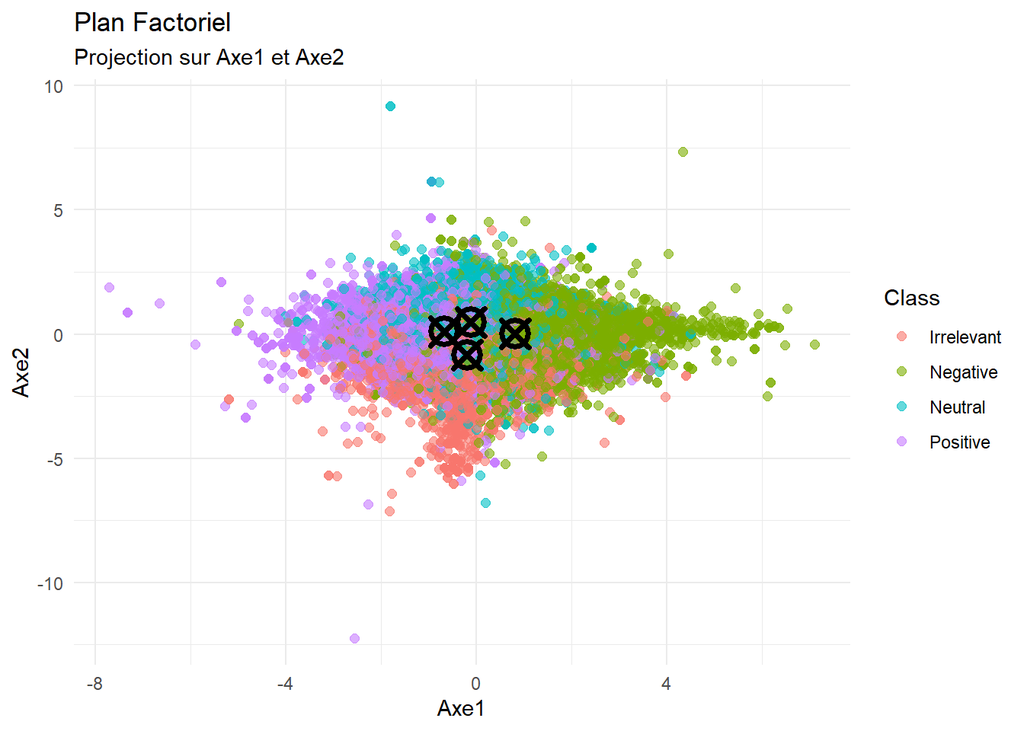

```r
library(ggplot2)

AFD_graph<- function(scores_df, x_axis, y_axis, title) {
  centers <- aggregate(scores_df[, c(x_axis, y_axis)], list(Class = scores_df$Class), mean)
  colnames(centers)[1] <- "Class" # On s'assure que la colonne s'appelle Class

  ggplot(scores_df, aes_string(x = x_axis, y = y_axis, color = "Class")) +
    geom_point(size = 2, alpha = 0.6) +
    geom_point(data = centers, aes_string(x = x_axis, y = y_axis, color = "Class"),
               shape = 13, size = 5, stroke = 2, color = "black") +
    labs(title = title,
         subtitle = paste("Projection sur", x_axis, "et", y_axis),
         x = x_axis, y = y_axis) +
    theme_minimal() +
    theme(legend.position = "right")
}

prediction <- predict(modele_lda, data_train)
scores_df <- data.frame(prediction$x)

colnames(scores_df) <- c("Axe1", "Axe2", "Axe3")
scores_df$Class <- data_train$Sentiment


AFD_graph(scores_df, "Axe1", "Axe2", "Plan Factoriel")
```

On remarque que l’Axe 1 sépare bien les opposés, on voit bien que les points “Positive” sont d’un côté et les “Negative” sont de l’autre. C’est cohérent avec l’inertie que nous avons trouvé. Au centre on remarque que c’est beaucoup plus mélangé et les catégories “Neutral” et “Irrelevant” se chevauchent beaucoup. Cela parait logique car les tweets utilisent souvent des mots banals donc l’algorithme a du mal à les différencier. On remarque également que les groupes ne sont pas parfaitement séparés (en effet les couleurs se mélangent). On peut donc comprendre qu’avec de simple mots on ne peut pas toujours deviner le sentiment exact.

#### 4.2. Évaluation des performances

Afin de valider statistiquement notre modèle nous allons calculer la matrice de confusion. Elle va nous permettre de comparer les prédictions du modèle par rapport à la réalité

```r
library(caret)

pred_test <- predict(modele_lda, data_test)

cm <- confusionMatrix(data = factor(pred_test$class),
                      reference = factor(data_test$Sentiment))

print(cm$table)
```

```
##             Reference
## Prediction   Irrelevant Negative Neutral Positive
##   Irrelevant         80       29      34       22
##   Negative           30      150      64       39
##   Neutral            25       51     129       59
##   Positive           37       36      58      157
```

```r
cat("\nPrécision sur les nouvelles données \n")
```

```
##
## Précision sur les nouvelles données
```

```r
cat(round(cm$overall['Accuracy'] * 100, 2), "%")
```

```
## 51.6 %
```

```r
stats_par_classe <- as.data.frame(cm$byClass)

tableau_final <- stats_par_classe[, c("Precision", "Recall", "F1")]

kable(tableau_final, digits = 3, caption = "Performance pour chaque émotion") %>%
  kable_styling(bootstrap_options = c("striped", "hover", "condensed"), full_width = F)
```

Performance pour chaque émotion

|  | Precision | Recall | F1 |
| --- | --- | --- | --- |
| Class: Irrelevant | 0.485 | 0.465 | 0.475 |
| Class: Negative | 0.530 | 0.564 | 0.546 |
| Class: Neutral | 0.489 | 0.453 | 0.470 |
| Class: Positive | 0.545 | 0.567 | 0.556 |

On remarque que l’on obtient une précision de 51.6%, cela peut paraître bas mais il faut se rappeler qu’on a 4 choix possibles. Si on répondait au hasard, on aurait 25% de chances de répondre correctement. Donc notre modèle est presque deux fois meilleur que le hasard.

Lorsque l’on regarde les performances pour chaque émotion on remarque que les catégories Positive et Negative obtiennent les meilleurs scores. Le modèle a une précision de 54.5% pour le positif et 53% pour le négatif. Cela signifie que lorsqu’un tweet est classé dans l’une des catégories le modèle a une chance sur deux d’avoir raison ce qui reste quand même significatif face à quatre classes possibles.

Les émotions comme irrelevant ou neutral sont beaucoup plus compliquées à être reconnues par notre modèle.

### 5. Discussion et Conclusion

Dans ce projet, nous avons voulu voir si l’Analyse Factorielle Discriminante (AFD) était efficace pour pouvoir analyser des sentiments sur Twitter. Nous avons obtenu une précision finale de 51.6% donc on peut dire que la méthode fonctionne plutôt correctement pour dégager les grandes tendances mais cette méthode a quand même ses limites.

On a pu remarquer que le nettoyage des données était très important car sans tout le nettoyage, afin de tester le modèle sans aucune préparation on était à environ moins de 30% de précision ce qui signifie que notre modèle était presque pire que le hasard. En effet lorsque l’on a rajouté l’ajout du score de sentiment (LexicalScore) et la prise en compte du contexte, les résultats étaient plus bons. Cela nous prouve que l’algorithme a besoin qu’on l’aide en lui donnant un contexte et en préparant bien les données en amont.

Enfin, on peut dire que l’AFD a permis de montrer une capacité à bien savoir distinguer les émotions fortes (positives et négatives) mais elle a du mal à identifier la neutralité ou l’absence de sujet (irrelevant). Pour un modèle qui est purement statistique les résultats sont plutôt corrects car ça prouve que même sans comprendre le sens profond des phrases on peut quand même réussir à dégager des structures émotionnelles plutôt cohérentes.

### 6. Travaux futurs

Si l’on devait poursuire ce projet pour dépasser la barre des 52% de précision, il faudrait je pense arreter l’approche statistique classique (AFD sur TF-IDF) pour passer au Deep Learning.

En faisant quelques recherches sur Kaggle nous sommes tombées sur un projet très intéressant qui utilise DistilBERT. La méthode ne consiste pas seulement à compter la fréquence des mots, elle essaye également de comprendre le sens de la phrase, avec DistilBERT le modèle peut comprendre que le not est l’inverse de happy. On remarque qu’avec leur méthode ils ont pu avoir une précision de plus de 93% voici le projet réalisé https://www.kaggle.com/code/shtrausslearning/twitter-emotion-classification/notebook